# Session 3: Discriminant Analysis

Supervised classification with multivariate predictors

O Rodriguez de Rivera Ortega, PhD

University of Exeter

# 1 Session overview

## 1.1 What is this session about?

This session introduces **discriminant analysis**, with a focus on **linear discriminant analysis** (LDA).

Discriminant analysis is a **supervised multivariate method**. This means that we already know the group labels and want to use measured variables to separate or predict those groups.

In this session, we use the `palmerpenguins` dataset. The known group label is `species`, and the predictor variables are penguin body measurements:

- bill length;
- bill depth;
- flipper length;
- body mass.

The main question is:

> Can we use penguin measurements to predict which species a penguin belongs to?

## 1.2 Learning outcomes

By the end of this section, students should be able to:

- explain the purpose of linear discriminant analysis;
- distinguish supervised and unsupervised multivariate methods;
- fit an LDA model using `MASS::lda()`;
- visualise discriminant scores;
- predict group membership for new observations;
- produce and interpret a confusion matrix;
- interpret classification accuracy carefully;
- compare a simpler and fuller classification model.

# 2 Discriminant analysis in context

## 2.1 Continuity from PCA, clustering and GLMs

In previous sections, we looked at methods such as PCA and clustering.

**PCA** is unsupervised. It finds directions of maximum variation in the data, but it does not use group labels.

**Clustering** is also unsupervised. It tries to identify groups, but it does not know the species labels in advance.

**Discriminant analysis** is supervised. It uses known group labels to find combinations of variables that best separate those groups.

This connects to GLMs because the aim is prediction or classification. However, LDA is multivariate because it uses several continuous predictors at the same time to separate predefined groups.

## 2.2 PCA versus LDA

| PCA | LDA |
| --- | --- |
| Unsupervised | Supervised |
| Does not use group labels | Uses group labels |
| Finds axes of maximum variation | Finds axes of maximum group separation |
| Useful for exploration | Useful for classification |
| Groups may or may not appear separated | Groups are used directly to define separation |

PCA asks:

> What are the main gradients of variation in the data?

LDA asks:

> Which combinations of variables best separate known groups?

# 3 Intuition behind LDA

## 3.1 What does LDA do?

Linear discriminant analysis creates new axes called **linear discriminants**.

These axes are weighted combinations of the original variables. For example, a discriminant axis might combine information from bill length, bill depth, flipper length and body mass.

The weights are chosen so that the groups are separated as much as possible.

The first discriminant axis, `LD1`, gives the strongest separation among groups. The second discriminant axis, `LD2`, gives the next strongest separation.

With three species, LDA can produce at most two discriminant axes:

```r
number_of_species <- 3
number_of_discriminant_axes <- number_of_species - 1
number_of_discriminant_axes
```

```
## [1] 2
```

So, for Adelie, Chinstrap and Gentoo penguins, we can have two axes: `LD1` and `LD2`.

## 3.2 Why use a train-test split?

We split the data into a **training dataset** and a **test dataset**.

The training data are used to fit the model. The test data are used to check how well the model predicts observations that were not used for fitting.

This gives a more honest estimate of model performance.

For teaching purposes, we use a simple random split. In a full applied analysis, we might use repeated cross-validation or other resampling methods.

# 4 Setup

## 4.1 Packages

```r
install.packages(c("tidyverse", "palmerpenguins", "MASS"))
```

```r
library(tidyverse)
library(palmerpenguins)

theme_set(theme_minimal(base_size = 12))
```

We will use `MASS::lda()` for the LDA model. We will not load the full `MASS` package with `library(MASS)` because `MASS` contains a function called `select()`, which can conflict with `dplyr::select()`.

# 5 Prepare the data

## 5.1 Clean the penguin data

```r
penguins_clean <- palmerpenguins::penguins %>%
  tidyr::drop_na(
    species,
    island,
    sex,
    bill_length_mm,
    bill_depth_mm,
    flipper_length_mm,
    body_mass_g
  ) %>%
  dplyr::mutate(
    species = factor(species),
    island = factor(island),
    sex = factor(sex)
  )

dplyr::glimpse(penguins_clean)
```

```
## Rows: 333
## Columns: 8
## $ species           <fct> Adelie, Adelie, Adelie, Adelie, Adelie, Adelie, Adel…
## $ island            <fct> Torgersen, Torgersen, Torgersen, Torgersen, Torgerse…
## $ bill_length_mm    <dbl> 39.1, 39.5, 40.3, 36.7, 39.3, 38.9, 39.2, 41.1, 38.6…
## $ bill_depth_mm     <dbl> 18.7, 17.4, 18.0, 19.3, 20.6, 17.8, 19.6, 17.6, 21.2…
## $ flipper_length_mm <int> 181, 186, 195, 193, 190, 181, 195, 182, 191, 198, 18…
## $ body_mass_g       <int> 3750, 3800, 3250, 3450, 3650, 3625, 4675, 3200, 3800…
## $ sex               <fct> male, female, female, female, male, female, male, fe…
## $ year              <int> 2007, 2007, 2007, 2007, 2007, 2007, 2007, 2007, 2007…
```

## 5.2 Explore the variables

```r
penguins_clean %>%
  dplyr::select(
    species,
    bill_length_mm,
    bill_depth_mm,
    flipper_length_mm,
    body_mass_g
  ) %>%
  dplyr::group_by(species) %>%
  dplyr::summarise(
    across(
      .cols = where(is.numeric),
      .fns = mean,
      .names = "mean_{.col}"
    ),
    .groups = "drop"
  )
```

```
## # A tibble: 3 × 5
##   species   mean_bill_length_mm mean_bill_depth_mm mean_flipper_length_mm
##   <fct>                   <dbl>              <dbl>                  <dbl>
## 1 Adelie                   38.8               18.3                   190.
## 2 Chinstrap                48.8               18.4                   196.
## 3 Gentoo                   47.6               15.0                   217.
## # ℹ 1 more variable: mean_body_mass_g <dbl>
```

Different species have different average body measurements. This suggests that the measurements may be useful for classification.

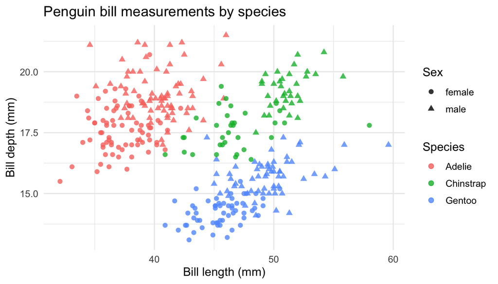

```r
ggplot(
  penguins_clean,
  aes(
    x = bill_length_mm,
    y = bill_depth_mm,
    colour = species,
    shape = sex
  )
) +
  geom_point(alpha = 0.8, size = 2) +
  labs(
    title = "Penguin bill measurements by species",
    x = "Bill length (mm)",
    y = "Bill depth (mm)",
    colour = "Species",
    shape = "Sex"
  )
```

# 6 Train-test split

## 6.1 Create training and test datasets

```r
set.seed(123)

train_id <- sample(
  seq_len(nrow(penguins_clean)),
  size = floor(0.7 * nrow(penguins_clean))
)

penguins_train <- penguins_clean[train_id, ]
penguins_test  <- penguins_clean[-train_id, ]

nrow(penguins_train)
```

```
## [1] 233
```

```r
nrow(penguins_test)
```

```
## [1] 100
```

The model will be fitted using the training data. We will then evaluate prediction accuracy using the test data.

# 7 Fit the full LDA model

## 7.1 LDA model

```r
lda_fit <- MASS::lda(
  species ~ bill_length_mm + bill_depth_mm + flipper_length_mm + body_mass_g,
  data = penguins_train
)

lda_fit
```

```
## Call:
## lda(species ~ bill_length_mm + bill_depth_mm + flipper_length_mm +
##     body_mass_g, data = penguins_train)
##
## Prior probabilities of groups:
##    Adelie Chinstrap    Gentoo
## 0.4420601 0.1888412 0.3690987
##
## Group means:
##           bill_length_mm bill_depth_mm flipper_length_mm body_mass_g
## Adelie          38.64854      18.33204          189.5146    3702.670
## Chinstrap       48.15227      18.36136          196.3636    3719.318
## Gentoo          47.48837      14.97791          217.1744    5075.872
##
## Coefficients of linear discriminants:
##                            LD1          LD2
## bill_length_mm    -0.065489759 -0.429687716
## bill_depth_mm      1.037566850 -0.063316900
## flipper_length_mm -0.076969482  0.004457771
## body_mass_g       -0.001494322  0.001885765
##
## Proportion of trace:
##    LD1    LD2
## 0.8715 0.1285
```

This model uses four continuous measurements to predict penguin species.

The output includes:

- prior probabilities for each species;
- group means for each predictor;
- coefficients of the discriminant axes.

The coefficients show how the original variables contribute to the linear discriminants. However, because the variables are correlated, the most useful interpretation often comes from the discriminant score plot.

# 8 Discriminant scores

## 8.1 Extract LDA scores

```r
lda_train_pred <- predict(lda_fit, newdata = penguins_train)

lda_scores <- as_tibble(lda_train_pred$x) %>%
  dplyr::bind_cols(
    penguins_train %>%
      dplyr::select(species, island, sex)
  )

head(lda_scores)
```

```
## # A tibble: 6 × 5
##     LD1    LD2 species   island    sex
##   <dbl>  <dbl> <fct>     <fct>     <fct>
## 1 -6.12 -3.23  Gentoo    Biscoe    male
## 2  4.59  2.17  Adelie    Torgersen female
## 3 -4.15  1.55  Gentoo    Biscoe    male
## 4  1.84 -2.88  Chinstrap Dream     male
## 5  2.03  0.270 Adelie    Torgersen male
## 6  1.30 -3.45  Chinstrap Dream     male
```

The columns `LD1` and `LD2` are the discriminant scores. These are the coordinates of each penguin in the new discriminant space.

## 8.2 Plot the LDA scores

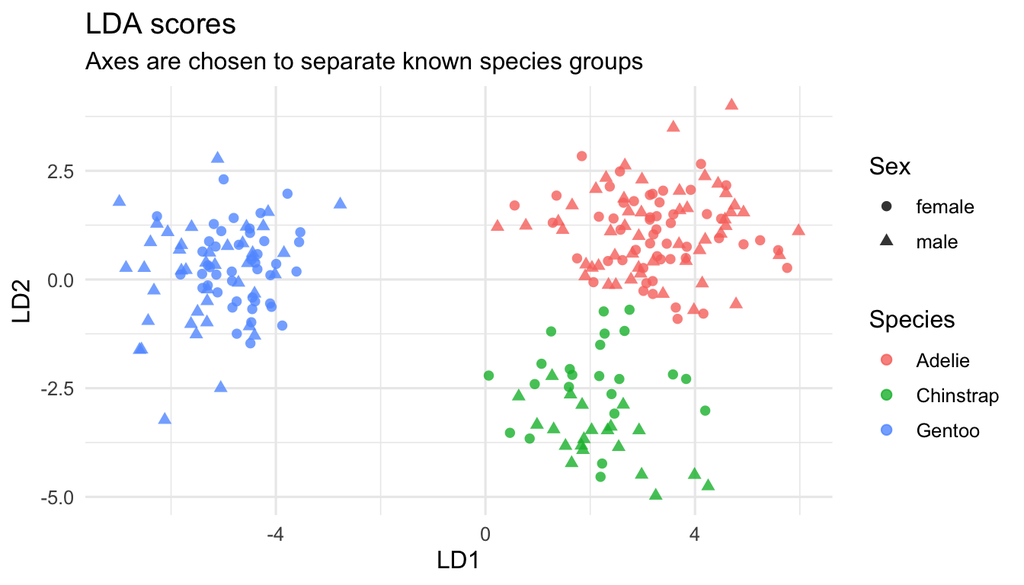

```r
ggplot(lda_scores, aes(x = LD1, y = LD2, colour = species, shape = sex)) +
  geom_point(alpha = 0.8, size = 2) +
  labs(
    title = "LDA scores",
    subtitle = "Axes are chosen to separate known species groups",
    x = "LD1",
    y = "LD2",
    colour = "Species",
    shape = "Sex"
  )
```

## 8.3 How to interpret the LDA score plot

The plot shows each penguin in the discriminant space.

Points close together have similar combinations of body measurements. Species that are far apart are easier to classify.

If two species overlap, the model may confuse them. For example, if Adelie and Chinstrap penguins overlap in the LDA plot, we would expect some misclassification between those two species.

The axes `LD1` and `LD2` are not original variables. They are combinations of the original measurements chosen to maximise separation among species.

# 9 Prediction

## 9.1 Predict the test data

```r
lda_test_pred <- predict(lda_fit, newdata = penguins_test)

predictions <- penguins_test %>%
  dplyr::select(species, island, sex) %>%
  dplyr::mutate(predicted_species = lda_test_pred$class)

head(predictions)
```

```
## # A tibble: 6 × 4
##   species island    sex    predicted_species
##   <fct>   <fct>     <fct>  <fct>
## 1 Adelie  Torgersen female Adelie
## 2 Adelie  Torgersen female Adelie
## 3 Adelie  Torgersen female Adelie
## 4 Adelie  Torgersen male   Adelie
## 5 Adelie  Biscoe    female Adelie
## 6 Adelie  Biscoe    male   Adelie
```

The predicted class is the species with the highest posterior probability.

# 10 Confusion matrix and accuracy

## 10.1 Confusion matrix

```r
conf_mat <- table(
  observed = predictions$species,
  predicted = predictions$predicted_species
)

conf_mat
```

```
##            predicted
## observed    Adelie Chinstrap Gentoo
##   Adelie        41         2      0
##   Chinstrap      0        24      0
##   Gentoo         0         0     33
```

The confusion matrix compares the observed species with the predicted species.

The diagonal values are correct classifications. The off-diagonal values are mistakes.

A useful way to read the confusion matrix is to ask:

- Which species are classified correctly most often?
- Which species are confused with each other?
- Are mistakes concentrated in one species pair?

## 10.2 Accuracy

```r
accuracy <- sum(diag(conf_mat)) / sum(conf_mat)
accuracy
```

```
## [1] 0.98
```

Accuracy is the proportion of correct predictions.

However, accuracy should not be the only metric. A model can have high overall accuracy but still perform poorly for one group.

# 11 Posterior probabilities

## 11.1 Extract posterior probabilities

```r
posterior <- as_tibble(lda_test_pred$posterior) %>%
  dplyr::bind_cols(
    predictions %>%
      dplyr::select(species, predicted_species)
  )

posterior %>%
  dplyr::slice_head(n = 10)
```

```
## # A tibble: 10 × 5
##    Adelie   Chinstrap   Gentoo species predicted_species
##     <dbl>       <dbl>    <dbl> <fct>   <fct>
##  1  1.000 0.000331    1.89e-12 Adelie  Adelie
##  2  0.963 0.0368      1.91e-14 Adelie  Adelie
##  3  1.000 0.000259    7.94e-18 Adelie  Adelie
##  4  0.870 0.130       5.22e-21 Adelie  Adelie
##  5  1.000 0.000000115 1.07e-19 Adelie  Adelie
##  6  1.000 0.00000638  3.98e-15 Adelie  Adelie
##  7  0.995 0.00493     1.07e-15 Adelie  Adelie
##  8  1.000 0.0000132   3.86e-21 Adelie  Adelie
##  9  1.000 0.000271    2.30e-22 Adelie  Adelie
## 10  0.998 0.00175     6.61e-15 Adelie  Adelie
```

Posterior probabilities measure classification confidence.

For example, if a penguin has posterior probabilities:

| Adelie | Chinstrap | Gentoo |
| --- | --- | --- |
| 0.10 | 0.15 | 0.75 |

then the predicted class is `Gentoo`.

A prediction with one very large posterior probability is confident. A prediction with two similar probabilities is less certain.

## 11.2 Plot posterior probabilities

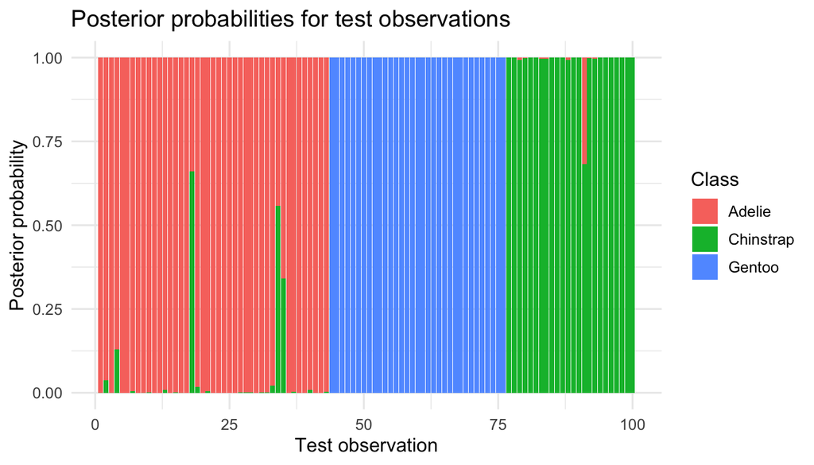

```r
posterior %>%
  dplyr::mutate(row = dplyr::row_number()) %>%
  tidyr::pivot_longer(
    cols = tidyselect::all_of(levels(penguins_clean$species)),
    names_to = "class",
    values_to = "probability"
  ) %>%
  ggplot(aes(x = row, y = probability, fill = class)) +
  geom_col(position = "stack") +
  labs(
    title = "Posterior probabilities for test observations",
    x = "Test observation",
    y = "Posterior probability",
    fill = "Class"
  )
```

Each bar represents one test observation. The largest section of the bar corresponds to the predicted species.

# 12 Interpretation and caution

## 12.1 What LDA assumes

LDA assumes that:

- predictors are continuous;
- group distributions are approximately multivariate normal;
- groups have similar covariance matrices;
- observations are independent.

These assumptions are often only approximate.

For teaching purposes, LDA is useful because it clearly connects multivariate measurements, group separation and prediction. For applied prediction problems, LDA should be compared with other methods and evaluated carefully using test data or cross-validation.

# 13 Practical exercise

## 13.1 Exercise: model comparison

1. Fit an LDA model using only bill length and bill depth.
2. Compare the accuracy with the full model.
3. Which species are most easily confused?
4. Would you prefer the simpler or fuller model for teaching interpretation?

```r
lda_bill <- MASS::lda(
  species ~ bill_length_mm + bill_depth_mm,
  data = penguins_train
)

lda_bill_pred <- predict(lda_bill, newdata = penguins_test)

table(
  observed = penguins_test$species,
  predicted = lda_bill_pred$class
)

mean(lda_bill_pred$class == penguins_test$species)
```

[output not shown]

# 14 Exercise solution

## 14.5 Which species are most easily confused?

The largest off-diagonal counts show which species are most often confused.

If Adelie and Chinstrap have the largest off-diagonal counts, then these two species are the most difficult to separate using only bill length and bill depth.

## 14.6 Simpler or fuller model?

The simpler model uses only bill length and bill depth. It is easier to interpret because classification is based only on bill morphology.

The full model also includes flipper length and body mass. It may classify species more accurately because it uses more information about overall body size.

For teaching interpretation, the simpler model may be preferable if its accuracy is close to the full model. It is easier to explain and visualise.

For prediction, the full model may be preferable if it has clearly higher accuracy.

# 15 Summary

In this session, we used LDA to classify penguin species from body measurements.

Key points:

- LDA is a supervised classification method.
- It uses known group labels.
- It finds linear combinations of predictors that separate groups.
- `LD1` and `LD2` are discriminant axes, not original variables.
- Confusion matrices help identify classification errors.
- Accuracy is useful but should be interpreted alongside class-specific mistakes.
- Posterior probabilities show classification confidence.

# 16 Transition to NMDS

LDA and PCA use continuous trait measurements.

The next session switches to ecological community data, where rows are sites and columns are species counts or abundances.

For community composition data, we often use distance-based methods such as NMDS, because we are interested in visualising similarity or dissimilarity among sites.